**City College of San Francisco**

MATH 108 - Foundations of Data Science

# Lecture 13: Conditionals and Iteration

Associated Textbook Sections: [9.0, 9.1, 9.2, 9.3](https://inferentialthinking.com/chapters/09/Randomness.html)

## Overview

- Comparison and Booleans
- Control Statements
- Random Selection
- Appending Arrays
- Iteration
- `bool` and `where`

## Set Up the Notebook

```python
from datascience import *
import numpy as np
%matplotlib inline
import matplotlib.pyplot as plots
plots.style.use('fivethirtyeight')
```

## Comparison and Booleans

### Comparison Operators

- Assignments Statements:
  - `x = 6`
  - `height = x * 12`
- Comparison Expressions:
  - `x > 1`
  - `x < y`
  - `y >= 3`
  - `x == y`
  - `x != y`
  - `2 < x < 5`
- The result of a comparison expression is a `bool` value (`True` or `False`)

### Aggregating Comparisons

- Summing an array or list of `bool` values will count the `True` values only.
- The following produce an output of `2`:
  - `1 + 0 + 1`
  - `True + False + True`
  - `sum([1, 0, 1])`
  - `sum([True, False, True])`

### Demo: Comparison

Demonstrate using the comparison operators.

```python
5 > 8
```

```
False
```

```python
type(5 > 8)
```

```
bool
```

```python
True
```

```
True
```

```python
# Creates a NameError
# true
```

```python
# Creates a SyntaxError
# 4 = 4
```

```python
3 == 3.0
```

```
True
```

```python
10 != 7
```

```
True
```

```python
x = 18
y = 5
```

```python
x > y
```

```
True
```

```python
x < 15
```

```
False
```

```python
5 < y
```

```
False
```

```python
# compound expression
1 < y < 10 < x
```

```
True
```

```python
y - x > 0
```

```
False
```

Introduce `and`, `or`, `not`.

```python
# For and, both have to be true
x > 10 and y > 7
```

```
False
```

```python
# For or, one (or both) has to be true
x > 10 or y >7
```

```
True
```

### Demo: Comparisons with Arrays

Demonstrate how comparisons work with arrays.

```python
pets = make_array('cat', 'cat', 'dog', 'cat', 'dog', 'rabbit')
```

```python
# checks each element of the array against 'cat' and posts True/False
pets == 'cat'
```

```
array([ True,  True, False,  True, False, False], dtype=bool)
```

```python
1 + 1 + 0 + 1 + 0 + 0
```

```
3
```

```python
# Python will count up Trues in an array (True is 1 and False is 0)
sum(make_array(True, True, False, True, False, False))
```

```
3
```

```python
sum(pets == 'dog')
```

```
2
```

```python
# np.count_nonzero counts the number of nonzero - or True- elements in an array

np.count_nonzero([0, 1, 1, 0, 1, 0, 1])
```

```
4
```

```python
# back to pets array, checking for 'dog'
pets == 'dog'
np.count_nonzero(pets == 'dog')
```

```
2
```

```python
# new array from arange, and the conditional makes a new array checking for > 28

x = np.arange(20, 31)
x > 28
```

```
array([False, False, False, False, False, False, False, False, False,
        True,  True], dtype=bool)
```

## Control Statements

### Control Statements

These statements control the sequence of computations that are performed in a program

- The keywords `if` and `for` begin control statements
- The purpose of `if` is to choose different code segments based on their arguments.

### Demo: Simulation

Consider the following game where each of 2 players rolls a die.

- The player with the smaller value pays the other player one dollar.
- If there is a tie, then no one pays anything.

Find a way to simulate one round of the game where each player rolls a die. It might help to think from the perspective of one of the players.

```python
# Work in progress (we will build from here)
# first define a function that takes the two die rolls and spits out the result

def one_round(player1, player2):
    if player1 > player2:
        return 1
```

```python
# check
one_round(5, 4)
```

```
1
```

```python
# check    There will be no output.
one_round(3, 5)
```

```python
# now re-define so it spits out something for the other situations
def one_round(player1, player2):
    if player1 > player2:
        player1_value = 1
    elif player1 < player2:
        player1_value = -1
    else:
        player1_value = 0
    return player1_value
```

```python
# Check
one_round(1, 2)
```

```
-1
```

```python
one_round(2, 2)
```

```
0
```

```python
one_round(3, 2)
```

```
1
```

## Random Selection

### Random Selection

The command

`np.random.choice(some_array, sample_size)`

creates an array by selecting a number (`sample_size`) of values uniformly at random with replacement from an array (`some_array`).

### Demo: Random Selection

Demonstrate how to use `np.random.choice`.

```python
mornings = make_array('wake up', 'sleep in')
```

```python
np.random.choice(mornings)
```

```
'sleep in'
```

```python
np.random.choice(mornings)
```

```
'wake up'
```

```python
np.random.choice(mornings)
```

```
'sleep in'
```

```python
# samples, with replacement, from the 2-element array mornings
# makes an array with 7 elements

np.random.choice(mornings, 7)
```

```
array(['sleep in', 'sleep in', 'wake up', 'sleep in', 'sleep in',
       'sleep in', 'wake up'],
      dtype='<U8')
```

```python
# if we want to count how many 'wake up's there are for example
# note this array is most likely not the same as above because it is taking a new
# random sample every time

sum(np.random.choice(mornings, 8) == 'wake up')
```

```
3
```

```python
sum(np.random.choice(mornings, 8) == 'sleep in')
```

```
5
```

```python
# if we wanted it to be static, we'd have to assign the random choice array
# to some variable and then it would be static

sample_week = np.random.choice(mornings, 7)
sample_week
```

```
array(['wake up', 'sleep in', 'sleep in', 'sleep in', 'wake up',
       'sleep in', 'wake up'],
      dtype='<U8')
```

```python
sum(sample_week == 'wake up')
```

```
3
```

```python
sum(sample_week == 'sleep in')
```

```
4
```

Create an array that represents the faces of a single six-sided die.

```python
# back to simulation of game

die_roll = np.arange(1, 7)
die_roll
```

```
array([1, 2, 3, 4, 5, 6])
```

Create a function that simulates one round of the game described earlier by randomly generating the rolls.

```python
np.random.choice(die_roll)
```

```
4
```

```python
# uses one_round above, and has no argument

def simulate_one_round():
    player1 = np.random.choice(die_roll)
    player2 = np.random.choice(die_roll)
    return one_round(player1, player2)
```

```python
simulate_one_round()
```

```
-1
```

## Appending Arrays

### A Longer Array

- `np.append(array_1, value)`
  - new array with value appended to `array_1`
  - `value` has to be of the same type as elements of `array_1`
- `np.append(array_1, array_2)`
  - new array with `array_2` appended to `array_1`
  - `array_2` elements must have the same type as `array_1` elements

### Demo: Appending Arrays

Demonstrate how to append values to an array.

```python
first = np.arange(4)
second = np.arange(10, 17)
```

```python
# adds 8 on to the end of first arrray
np.append(first, 8)
```

```
array([0, 1, 2, 3, 8])
```

```python
# first is unchanged
first
```

```
array([0, 1, 2, 3])
```

```python
np.append(first, second)
```

```
array([ 0,  1,  2,  3, 10, 11, 12, 13, 14, 15, 16])
```

```python
# first and second are unchanged
first
```

```
array([0, 1, 2, 3])
```

```python
second
```

```
array([10, 11, 12, 13, 14, 15, 16])
```

### Demo: Repeated Betting

Store the results of the simulated game in an array for each player. First, create an empty array.

```python
# creating an empty array
player1_results = make_array()
player1_results
```

```
array([], dtype=float64)
```

```python
# simulate a round and then append the results into the player1_results array
player1_results = np.append(player1_results, simulate_one_round())
player1_results
```

```
array([-1.])
```

## Iteration

### `for` Statements

- `for` is a keyword that begins a control statement
- The purpose of `for` is to perform a computation for every element in a list or array

### Demo: `for` Statements

Demonstrate how `for` statements work.

```python
# in the for statement, pet takes each element in the array and puts it in the print statement

for pet in make_array('cat', 'dog', 'rabbit'):
    print('I love my ' + pet)
```

```
I love my cat
I love my dog
I love my rabbit
```

```python
# This is what it's doing. Running through the 1st, 2nd, third item and doing the same thing to each

pet = make_array('cat', 'dog', 'rabbit').item(0)
print('I love my ' + pet)

pet = make_array('cat', 'dog', 'rabbit').item(1)
print('I love my ' + pet)

pet = make_array('cat', 'dog', 'rabbit').item(2)
print('I love my ' + pet)
```

```
I love my cat
I love my dog
I love my rabbit
```

Simulate and the store results of 10,000 iterations of the game described earlier.

```python
# Do for 5 iterations to see what happens

player1_game_outcomes = make_array()

for i in np.arange(5):
    player1_game_outcomes = np.append(player1_game_outcomes, simulate_one_round())

player1_game_outcomes
```

```
array([-1., -1.,  1., -1.,  1.])
```

```python
# Up to 10000 (we can adjust repetitions)

player1_game_outcomes = make_array()
repetitions = 10000

for i in np.arange(repetitions):
    player1_game_outcomes = np.append(player1_game_outcomes, simulate_one_round())

player1_game_outcomes
```

```
array([ 1.,  1.,  0., ...,  1.,  0., -1.])
```

```python
len(player1_game_outcomes)
```

```
10000
```

Create a table with the results of the game and visualize the results for Player 1.

```python
results = Table().with_columns(
    'Player 1 Outcomes', player1_game_outcomes,
    'Player 2 Outcomes', -1 * player1_game_outcomes
)
results

# This yeilds -0 for ties, but -0, +0, and 0 are all the same
```

| Player 1 Outcomes | Player 2 Outcomes |
| --- | --- |
| 1 | -1 |
| 1 | -1 |
| 0 | -0 |
| 1 | -1 |
| 1 | -1 |
| 0 | -0 |
| 1 | -1 |
| -1 | 1 |
| -1 | 1 |
| 1 | -1 |

... (9990 rows omitted)

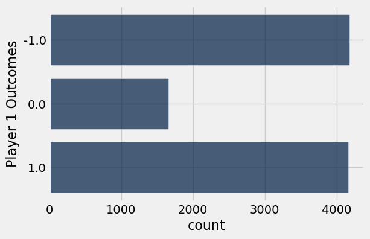

```python
results.group('Player 1 Outcomes').barh('Player 1 Outcomes')
```

### Demo: Simulating Heads in 100 Coin Tosses

Create a fair coin and develop the components to simulate flipping the coin 100 times. Make sure to keep track of the results where the simulation is repeated 10,000 times.

```python
# start by making an array of possible outcomes for one flip

coin_flip = make_array('heads', 'tails')
```

```python
# to check it's fair, note we are setting it up to count 'heads',
# but we could alternatively use 'tails'

sum(np.random.choice(coin_flip, 100) == 'heads')
```

```
56
```

```python
# Simulate one outcome for 100 flips and counting the number of heads

def num_heads():
    return sum(np.random.choice(coin_flip, 100) == 'heads')
```

```python
# Decide how many times you want to repeat the experiment

repetitions = 10000
```

```python
# Simulate that many outcomes, start with empty array
# each iteration adds the results on to the end of the outcomes array

outcomes = make_array()

for i in np.arange(repetitions):
    outcomes = np.append(outcomes, num_heads())
```

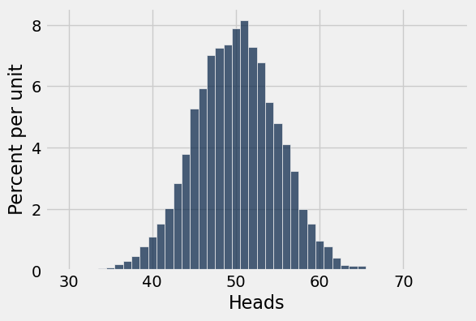

```python
# bin choice (since all values are integers, we can make bins 1 wide starting on the half
# to make it as fine-grained as possible)

heads = Table().with_column('Heads', outcomes)
heads.hist(bins = np.arange(29.5, 75.6))
```

## `bool` and `where`

### A Closer Look at `where`

The command

`t.where(array_of_bool_values)`

returns a table with only the rows of `t` for which the corresponding `bool` is `True`.

### Demo: Advanced `where`

Demonstrate how to use conditionals with the `where` method.

```python
# makes a single column table of ages for demonstration
# say we wanted to gather those 18 or over and make a new table called voters

ages = make_array(16, 22, 18, 15, 19, 15, 16, 21)
age = Table().with_column('Age', ages)
age
```

| Age |
| --- |
| 16 |
| 22 |
| 18 |
| 15 |
| 19 |
| 15 |
| 16 |
| 21 |

```python
# the way we know (using Table methods)

age.where('Age', are.above_or_equal_to(18))
```

| Age |
| --- |
| 22 |
| 18 |
| 19 |
| 21 |

```python
# this goes through the ages array and labels True/False

voter = ages >= 18
```

```python
voter
```

```
array([False,  True,  True, False,  True, False, False,  True], dtype=bool)
```

```python
age.where(voter)
```

| Age |
| --- |
| 22 |
| 18 |
| 19 |
| 21 |

```python
# set this condition to is_voter

is_voter = are.above_or_equal_to(18)
```

```python
type(is_voter)
```

```
datascience.predicates._combinable
```

```python
# can call is_voter on a value

is_voter(22)
```

```
True
```

```python
is_voter(3)
```

```
False
```

```python
# can apply the is_voter condition to each element in the 'Age' column of age table

age.apply(is_voter, 'Age')
```

```
array([False,  True,  True, False,  True, False, False,  True], dtype=bool)
```

```python
# can also apply the condition to each element in the ages array

ages >= 18
```

```
array([False,  True,  True, False,  True, False, False,  True], dtype=bool)
```

```python
# the same (done above)

voter
```

```
array([False,  True,  True, False,  True, False, False,  True], dtype=bool)
```

```python
# could create a function to check if age, x, is a voter

def my_voter_function(x):
    return x >= 18
```

```python
# recall from above

age.where('Age', are.above_or_equal_to(18))
```

| Age |
| --- |
| 22 |
| 18 |
| 19 |
| 21 |

```python
age.where(voter)
```

| Age |
| --- |
| 22 |
| 18 |
| 19 |
| 21 |

```python
# now apply the function and get same result

age.where('Age', my_voter_function)
```

| Age |
| --- |
| 22 |
| 18 |
| 19 |
| 21 |